# Homework on SFPD Data

Yun-Hui Liu

4/22/2017

This homework requires you to analyze crime data from San Francisco, using exploratory data analysis (EDA). This is a **group** homework.

Q1: Read in the data using the **fread()** function in R. How many rows and columns of data do you have? The file is “SFPD_Incidents_from_January_2003.csv”.

```r
library(data.table)
SFPD<-fread("SFPD_Incidents_from_January_2003.csv")
```

[output not shown]

```r
dim(SFPD)
```

```
## [1] 2047932      13
```

Q2: How many different types of crime categories are there? Print them out.

```r
length(unique(SFPD$Category))
```

```
## [1] 39
```

```r
print(unique(SFPD$Category))
```

```
##  [1] "NON-CRIMINAL"                "ROBBERY"
##  [3] "ASSAULT"                     "SECONDARY CODES"
##  [5] "VANDALISM"                   "BURGLARY"
##  [7] "LARCENY/THEFT"               "DRUG/NARCOTIC"
##  [9] "WARRANTS"                    "VEHICLE THEFT"
## [11] "OTHER OFFENSES"              "WEAPON LAWS"
## [13] "ARSON"                       "MISSING PERSON"
## [15] "DRIVING UNDER THE INFLUENCE" "SUSPICIOUS OCC"
## [17] "RECOVERED VEHICLE"           "DRUNKENNESS"
## [19] "TRESPASS"                    "FRAUD"
## [21] "DISORDERLY CONDUCT"          "SEX OFFENSES, FORCIBLE"
## [23] "FORGERY/COUNTERFEITING"      "KIDNAPPING"
## [25] "EMBEZZLEMENT"                "STOLEN PROPERTY"
## [27] "LIQUOR LAWS"                 "FAMILY OFFENSES"
## [29] "LOITERING"                   "BAD CHECKS"
## [31] "TREA"                        "GAMBLING"
## [33] "RUNAWAY"                     "BRIBERY"
## [35] "PROSTITUTION"                "PORNOGRAPHY/OBSCENE MAT"
## [37] "SEX OFFENSES, NON FORCIBLE"  "SUICIDE"
## [39] "EXTORTION"
```

Q3: Plot the total incidence of crime over time by year using the **ggplot** package. Label the axes properly and make sure the plot is complete and looks good.

```r
library(lubridate)
```

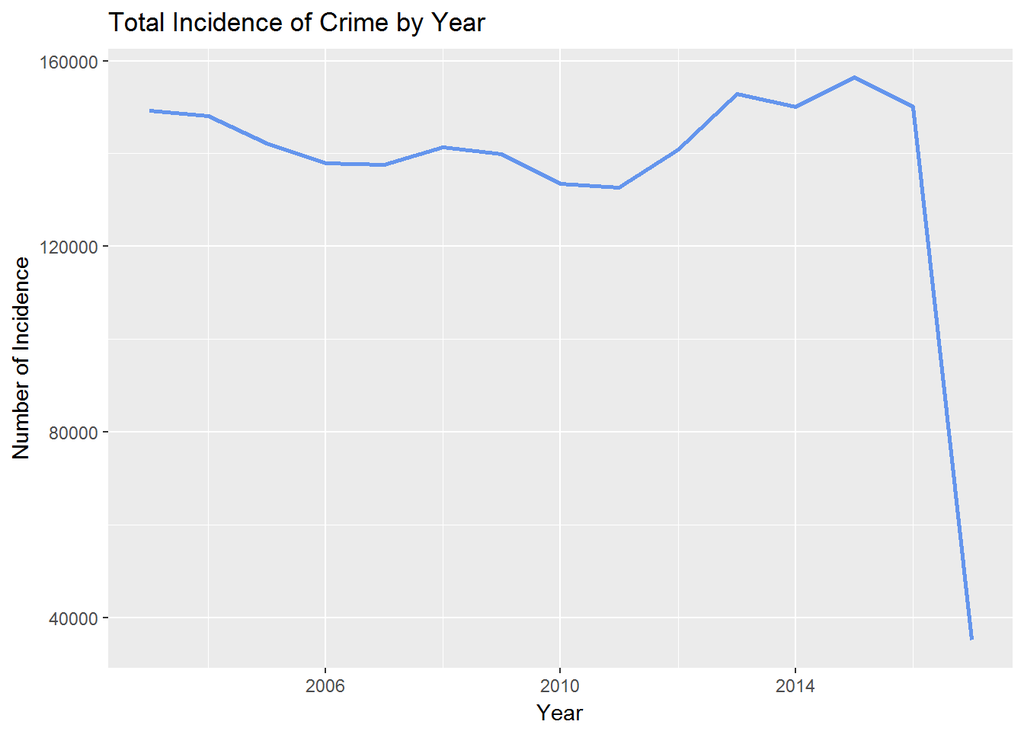

```r
SFPD$Cdate<-mdy(SFPD$Date)
SFPD$Cyear<-year(SFPD$Cdate)
SFPD$Count<-1
df<-aggregate(Count~Cyear,SFPD,sum)

library(ggplot2)
ggplot(df,aes(x=Cyear,y=Count))+geom_line(colour="cornflowerblue",lwd=1)+ggtitle("Total Incidence of Crime by Year")+xlab("Year")+ylab("Number of Incidence")
```

Q4: Create a table to show the frequency of all crimes over time. This data frame should have one column per crime. Be careful to handle missing values as all crimes may not occur every year. Print out the top of this data frame.

```r
library(plyr)
x<-xtabs(~Cyear+Category,SFPD)
head(x,n=15)
```

```
##       Category
## Cyear  ARSON ASSAULT BAD CHECKS BRIBERY BURGLARY DISORDERLY CONDUCT
##   2003   293   13461        134      28     6047                886
##   2004   280   12899         79      39     6753                814
##   2005   231   11601        101      38     7071                687
##   2006   240   12449         87      36     7004                521
##   2007   246   12518         69      56     5454                581
##   2008   248   12681         78      49     5679                789
##   2009   222   12284         64      46     5379                956
##   2010   209   12387         54      61     4966                827
##   2011   203   12279         45      47     4987                762
##   2012   237   12181         49      64     6243                704
##   2013   248   12580         26      69     6195                464
##   2014   253   12402         34      56     6066                345
##   2015   311   13115         38      73     5931                551
```

[output cut: 138 more lines]

```r
df1<-as.data.frame.matrix(x)
```

Q5: Compute the correlations of all crimes and report top 10 pairs of crimes that are most correlated.

```r
y<-cor(df1)
dt<-as.data.table(as.table(y))
correlation<-dt[order(N)]
print(correlation[1463:1482,])
```

```
##                         V1                     V2         N
##  1:            WEAPON LAWS              VANDALISM 0.9140897
##  2:              VANDALISM            WEAPON LAWS 0.9140897
##  3:            WEAPON LAWS         MISSING PERSON 0.9149553
##  4:         MISSING PERSON            WEAPON LAWS 0.9149553
##  5:           PROSTITUTION          DRUG/NARCOTIC 0.9211487
##  6:          DRUG/NARCOTIC           PROSTITUTION 0.9211487
##  7:           NON-CRIMINAL          LARCENY/THEFT 0.9260638
##  8:          LARCENY/THEFT           NON-CRIMINAL 0.9260638
##  9:                SUICIDE           EMBEZZLEMENT 0.9305213
## 10:           EMBEZZLEMENT                SUICIDE 0.9305213
## 11:        STOLEN PROPERTY           NON-CRIMINAL 0.9365495
## 12:           NON-CRIMINAL        STOLEN PROPERTY 0.9365495
## 13:                  FRAUD                ASSAULT 0.9407685
## 14:                ASSAULT                  FRAUD 0.9407685
## 15:         SUSPICIOUS OCC         MISSING PERSON 0.9444869
## 16:         MISSING PERSON         SUSPICIOUS OCC 0.9444869
## 17:            LIQUOR LAWS          DRUG/NARCOTIC 0.9461114
## 18:          DRUG/NARCOTIC            LIQUOR LAWS 0.9461114
## 19:            WEAPON LAWS SEX OFFENSES, FORCIBLE 0.9485275
## 20: SEX OFFENSES, FORCIBLE            WEAPON LAWS 0.9485275
```

Q6: Plot all the crimes by year to see how they evolve. Choose any plot type you think will be the best visualization of the data. Make sure this is something readable and not a mess!

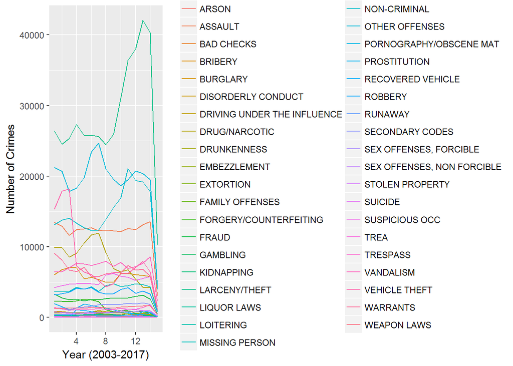

```r
sa<-stack(as.data.frame(df1))
sa$year<-rep(seq_len(nrow(df1)),ncol(df1))
qplot(year,values,data=sa,group=ind,colour=ind,geom="line",xlab="Year (2003-2017)",ylab="Number of Crimes")
```

Q7: Create a pie chart of all crimes (aggregate across all years).

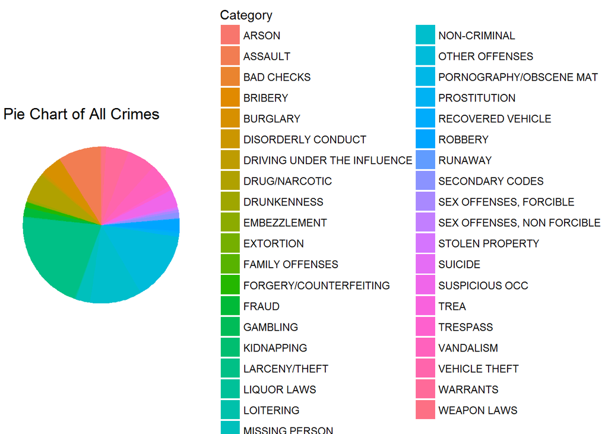

```r
df2<-aggregate(Count~Category,SFPD,sum)
ggplot(df2,aes(x="",y=Count,fill=Category))+geom_bar(width=1,stat="identity")+coord_polar(theta="y")+theme_void()+ggtitle("Pie Chart of All Crimes")
```

Q8: Plot the total crimes by lattitude and longitude, for all combinations of police district and crime category, using a scatter plot. Make the scatter plot interactive using the **rbokeh** package.

```r
library(rbokeh)
colnames(SFPD)[10]<-"lng"
colnames(SFPD)[11]<-"lat"
data <- subset(SFPD, Category=='BRIBERY'|Category=='SUICIDE')
gmap(lat=37.78,lng=-122.42,zoom=12,width=480,height=480,map_type="hybrid")%>% ly_points(lng,lat,data=data,col='red',hover=c(PdDistrict,Category))
```

[interactive chart not shown]

Since if we use the whole data to plot on google map, the size of the HTML file will become too large, we used only two kinds of crimes in this graph. We only need to change the data=data to data=SFPD if we want the whole data plot.

Q9: Using annual counts, how much of DRUG/NARCOTIC offences can you explain using the number of LIQOUR LAWS, PROSTITUTION, and WEAPON LAWS violations?

```r
AnnualCounts<-as.data.frame.matrix(x)
reg<-lm(AnnualCounts[,8]~AnnualCounts[,18]+AnnualCounts[,24]+AnnualCounts[,39])
summary(reg)
```

```
##
## Call:
## lm(formula = AnnualCounts[, 8] ~ AnnualCounts[, 18] + AnnualCounts[,
##     24] + AnnualCounts[, 39])
##
## Residuals:
##      Min       1Q   Median       3Q      Max
## -1005.88  -596.01   -23.24   399.58  1426.21
##
## Coefficients:
##                     Estimate Std. Error t value Pr(>|t|)
## (Intercept)         389.8031  1098.2128   0.355  0.72934
## AnnualCounts[, 18]   14.3374     4.0158   3.570  0.00439 **
## AnnualCounts[, 24]    2.4294     0.7877   3.084  0.01039 *
## AnnualCounts[, 39]    0.6411     0.8375   0.765  0.46009
## ---
## Signif. codes:  0 '***' 0.001 '**' 0.01 '*' 0.05 '.' 0.1 ' ' 1
##
## Residual standard error: 831.8 on 11 degrees of freedom
## Multiple R-squared:  0.9438, Adjusted R-squared:  0.9285
## F-statistic: 61.61 on 3 and 11 DF,  p-value: 3.649e-07
```

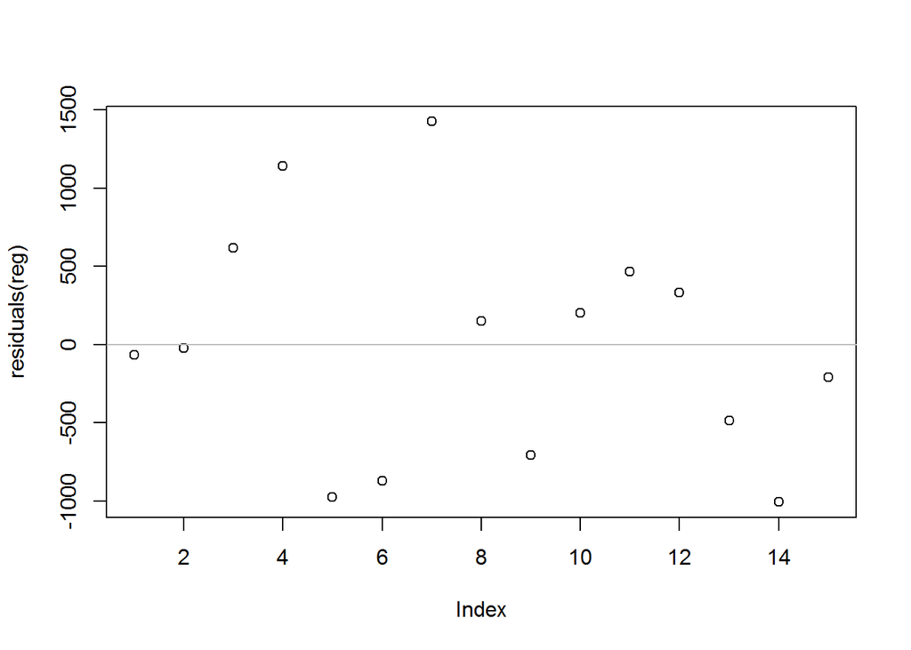

```r
plot(residuals(reg))
abline(h=0,col="gray")
```

Q10: How would you show in one picture, which crimes occur together the most?

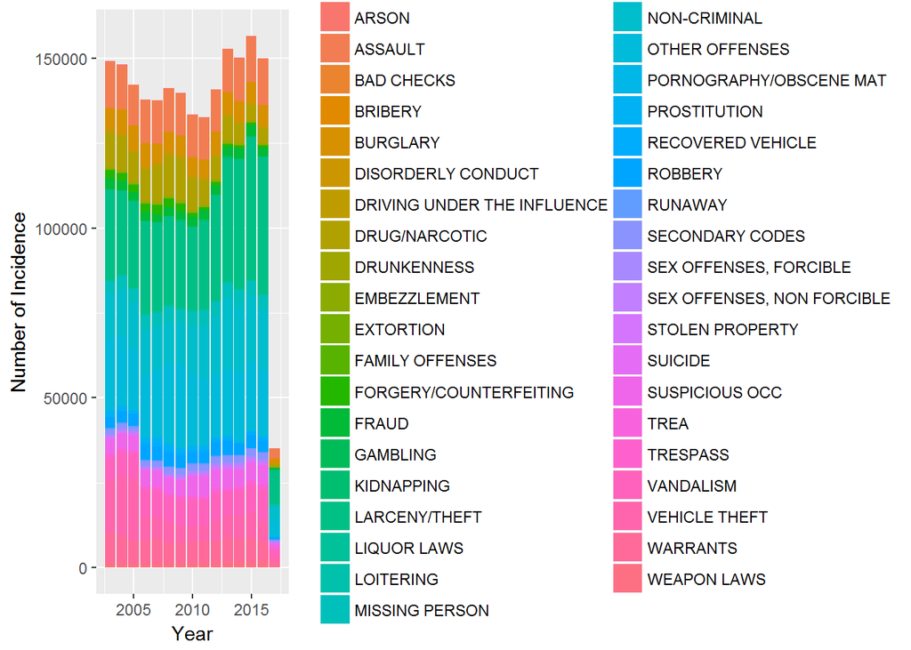

```r
Tmost<-subset(SFPD,select=c("Category","Cdate","Cyear","Count"))
ggplot(Tmost,aes(x=Cyear,y=Count,fill=Category))+geom_bar(stat="identity")+xlab("Year")+ylab("Number of Incidence")
```